# Tarea 4

Ponderación: 12% de la nota final del curso Formato: Desarrollar esta tarea en un`Rmarkdown`.

## Instrucciones:

Usa el siguiente cógigo para cargar la base de datos sobre Covid-19 usados en clase:

```r
library("tidyverse")
library("wesanderson")
library("cowplot")
library("lubridate")
library("viridis")
library("ggdark")

path <- url("https://raw.githubusercontent.com/mebucca/dar_soc4001/master/slides/class_12/covid_data.csv")
# leer archivo csv
covid_data <- read_delim(path, delim=";")
```

Referencia: Hasell, J., Mathieu, E., Beltekian, D. et al. A cross-country database of COVID-19 testing. Sci Data 7, 345 (2020). [Link](https://doi.org/10.1038/s41597-020-00688-8)

Los datos deben verse así:

```
## Rows: 56,748
## Columns: 50
## $ iso_code                           <chr> "AFG", "AFG", "AFG", "AFG", "AFG", …
## $ continent                          <chr> "Asia", "Asia", "Asia", "Asia", "As…
## $ location                           <chr> "Afghanistan", "Afghanistan", "Afgh…
## $ date                               <date> 2019-12-31, 2020-01-01, 2020-01-02…
## $ total_cases                        <dbl> NA, NA, NA, NA, NA, NA, NA, NA, NA,…
## $ new_cases                          <dbl> 0, 0, 0, 0, 0, 0, 0, 0, 0, 0, 0, 0,…
## $ new_cases_smoothed                 <dbl> NA, NA, NA, NA, NA, NA, 0, 0, 0, 0,…
## $ total_deaths                       <dbl> NA, NA, NA, NA, NA, NA, NA, NA, NA,…
## $ new_deaths                         <dbl> 0, 0, 0, 0, 0, 0, 0, 0, 0, 0, 0, 0,…
## $ new_deaths_smoothed                <dbl> NA, NA, NA, NA, NA, NA, 0, 0, 0, 0,…
## $ total_cases_per_million            <dbl> NA, NA, NA, NA, NA, NA, NA, NA, NA,…
## $ new_cases_per_million              <dbl> 0, 0, 0, 0, 0, 0, 0, 0, 0, 0, 0, 0,…
## $ new_cases_smoothed_per_million     <dbl> NA, NA, NA, NA, NA, NA, 0, 0, 0, 0,…
```

[output cut: 37 more lines]

## Ejercicio

Usando `Rmarkdown`, produce un reporte lo más parecido posible al documento que estás leyendo.

La figura a continuación usa un `theme` y una paleta de colores de tu preferencia. **Pista**: mi paleta de colores está definida por la siguiente linea de código: `scale_color_viridis(trans = "date", option = "plasma")` y mi theme es `dark_theme_gray()`, del paquete `library("ggdark")`. Ambos ejes están graficados en escala log10.

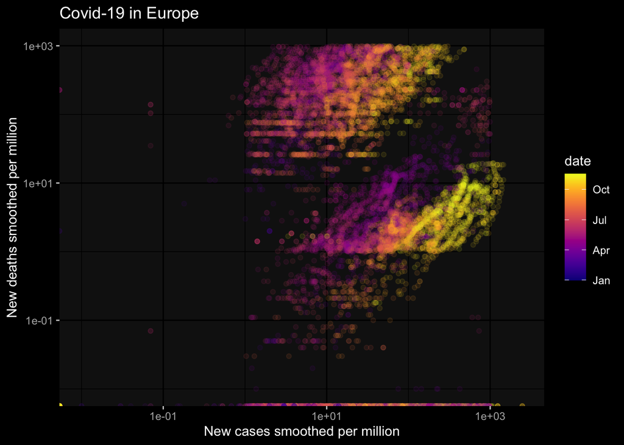

```r
plot <- covid_data  %>% filter(continent=="Europe") %>%
  ggplot(aes(x=new_cases_smoothed_per_million, y=new_deaths_smoothed_per_million, colour=date)) +
  geom_point(alpha=0.1) +
  scale_x_log10() +  scale_y_log10() +
  dark_theme_gray() +
  scale_color_viridis(trans = "date", option = "plasma") +
  labs(x="New cases smoothed per million", y="New deaths smoothed per million", title="Covid-19 in Europe")

print(plot)
```